# EDA on NYC Test Scores Data

Ransford Hyman Jr.

December 15, 2015

```r
initial_reshape_function <- function(df,s){
  df <- subset(df, df$Grade != "All Grades")
  df$Grade <- as.integer(df$Grade)
  df$Mean.Scale.Score <- as.numeric(df$Mean.Scale.Score)
  df$Level1Percentage <- as.numeric(df$Level1Percentage)
  df$Level2Percentage <- as.numeric(df$Level2Percentage)
  df$Level3Percentage <- as.numeric(df$Level3Percentage)
  df$Level4Percentage <- as.numeric(df$Level4Percentage)
  df$Subject <- s
  df$Category <- factor(df$Category)
  df$Subject <- factor(df$Subject)
  return(df)
}
```

## Analyzing Test Data on a Borough-level Granulatrity 2013-2015

```r
setwd('C:\\Users\\ransf\\Documents\\BoroughData/')
df <- read.csv("BoroughELAResults20132015_ALL.csv")
df <- initial_reshape_function(df,"ELA")
```

```r
setwd('C:\\Users\\ransf\\Documents\\BoroughData/')
df1 <- read.csv("BoroughELAResults20132015_Gender.csv")
df1 <- initial_reshape_function(df1, "ELA")
```

```r
setwd('C:\\Users\\ransf\\Documents\\BoroughData/')
df2 <- read.csv("BoroughELAResults20132015_Ethnicity.csv")
df2 <- initial_reshape_function(df2, "ELA")
```

```r
setwd('C:\\Users\\ransf\\Documents\\BoroughData/')
df3 <- read.csv("BoroughELAResults20132015_ELL.csv")
df3 <- initial_reshape_function(df3, "ELA")
```

```r
library(dplyr)
ela.2013.2015 <- bind_rows(df,df1)
ela.2013.2015 <- bind_rows(ela.2013.2015,df2)
ela.2013.2015 <- bind_rows(ela.2013.2015,df3)
```

```r
rm(df, df1, df2, df3)
setwd('C:\\Users\\ransf\\Documents\\BoroughData/')
df <- read.csv("BoroughMathResults20132015_ALL.csv")
df <- initial_reshape_function(df, "Math")
```

```r
setwd('C:\\Users\\ransf\\Documents\\BoroughData/')
df1 <- read.csv("BoroughMathResults20132015_ELL.csv")
df1 <- initial_reshape_function(df1, "Math")
```

```r
setwd('C:\\Users\\ransf\\Documents\\BoroughData/')
df2 <- read.csv("BoroughMathResults20132015_Ethnicity.csv")
df2 <- initial_reshape_function(df2, "Math")
```

```r
setwd('C:\\Users\\ransf\\Documents\\BoroughData/')
df3 <- read.csv("BoroughMathResults20132015_Gender.csv")
df3 <- initial_reshape_function(df3, "Math")
```

```r
math.2013.2015 <- bind_rows(df,df1)
math.2013.2015 <- bind_rows(math.2013.2015,df2)
math.2013.2015 <- bind_rows(math.2013.2015,df3)

borough_data <- bind_rows(ela.2013.2015,math.2013.2015)
rm(ela.2013.2015,math.2013.2015)
rm(df, df1, df2, df3)
```

Let’s analyze how the mean test scores look across each Borough from 2013-2015

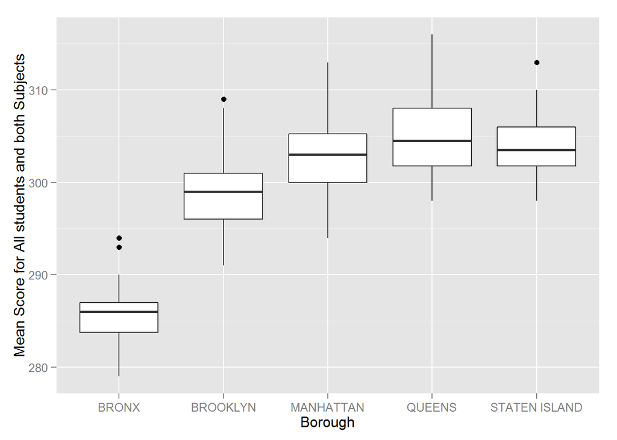

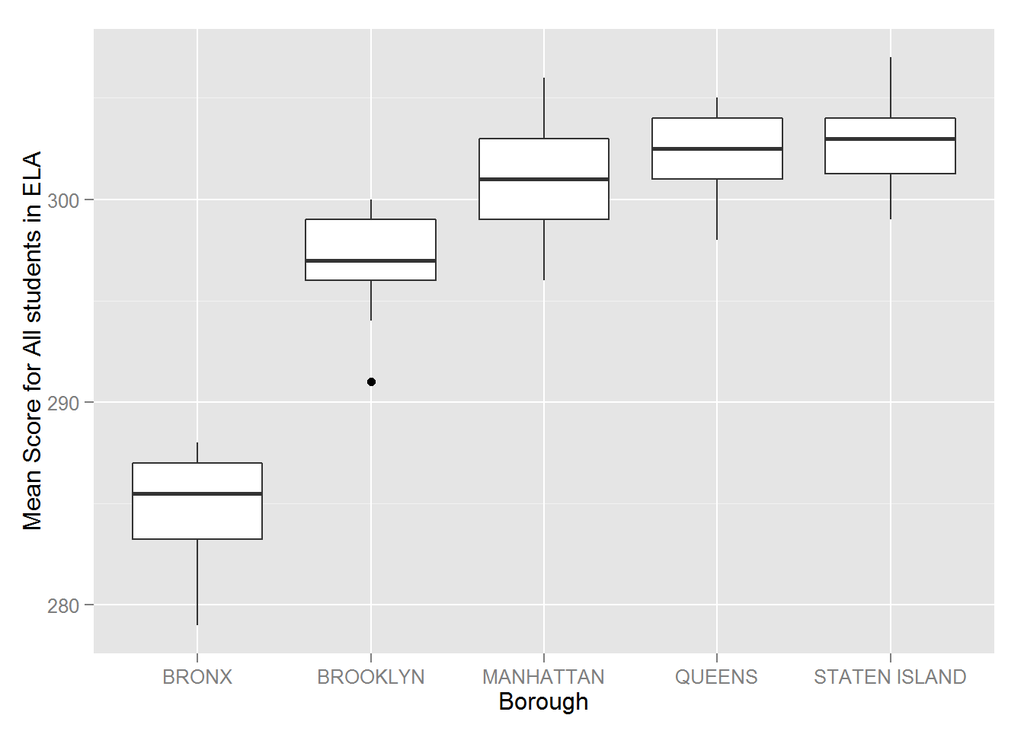

```r
ggplot(subset(borough_data,Category == "All Students" & Subject == "ELA"), aes(Borough,Mean.Scale.Score)) + geom_boxplot() +  ylab("Mean Score for All students in ELA")
```

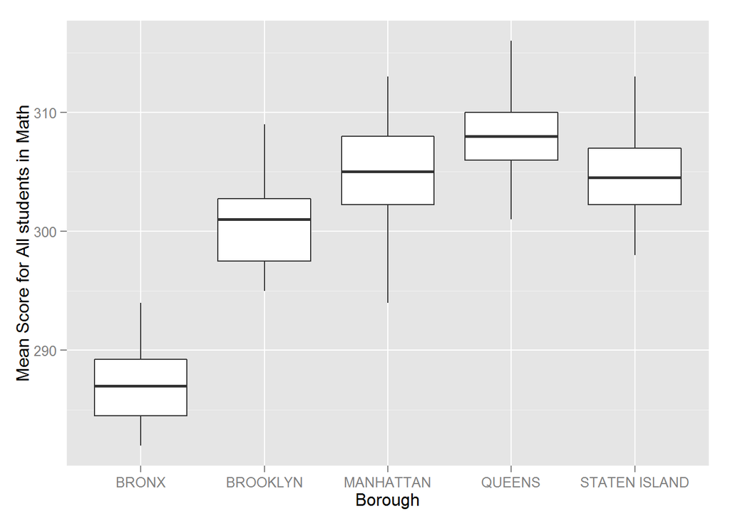

```r
ggplot(subset(borough_data,Category == "All Students" & Subject == "Math"), aes(Borough,Mean.Scale.Score)) + geom_boxplot() +  ylab("Mean Score for All students in Math")
```

From the plots, The Bronx has significantly lower test scores then the other boroughs. Staten Island has the higest median mean score in ELA while Queens has the highest median mean score in Mathematics. We now have a look at the scores by Gender across all boroughs.

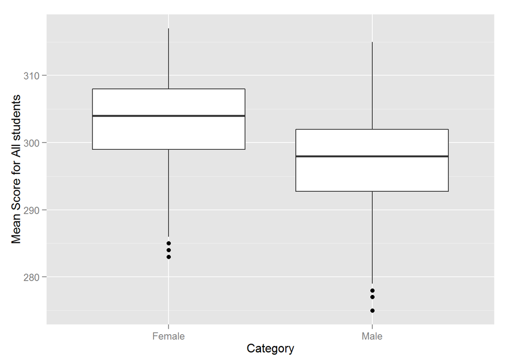

```r
ggplot(subset(borough_data,Category == c("Female", "Male")), aes(Category,Mean.Scale.Score)) + geom_boxplot() +  ylab("Mean Score for All students")
```

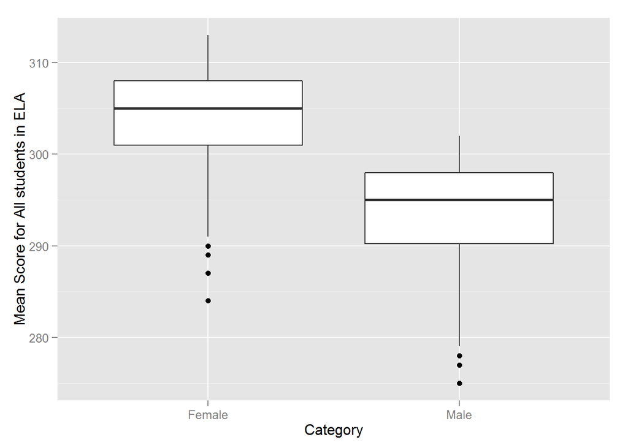

```r
ggplot(subset(borough_data,Category == c("Female", "Male") & Subject == "ELA"), aes(Category,Mean.Scale.Score)) + geom_boxplot() +  ylab("Mean Score for All students in ELA")
```

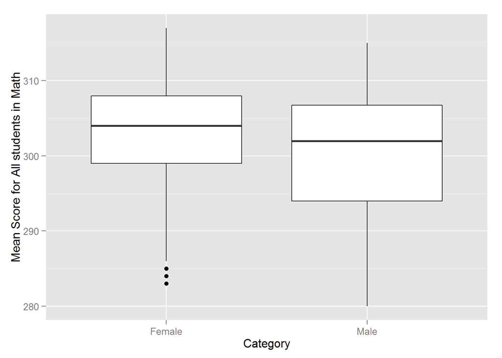

```r
ggplot(subset(borough_data,Category == c("Female", "Male") & Subject == "Math"), aes(Category,Mean.Scale.Score)) + geom_boxplot() +  ylab("Mean Score for All students in Math")
```

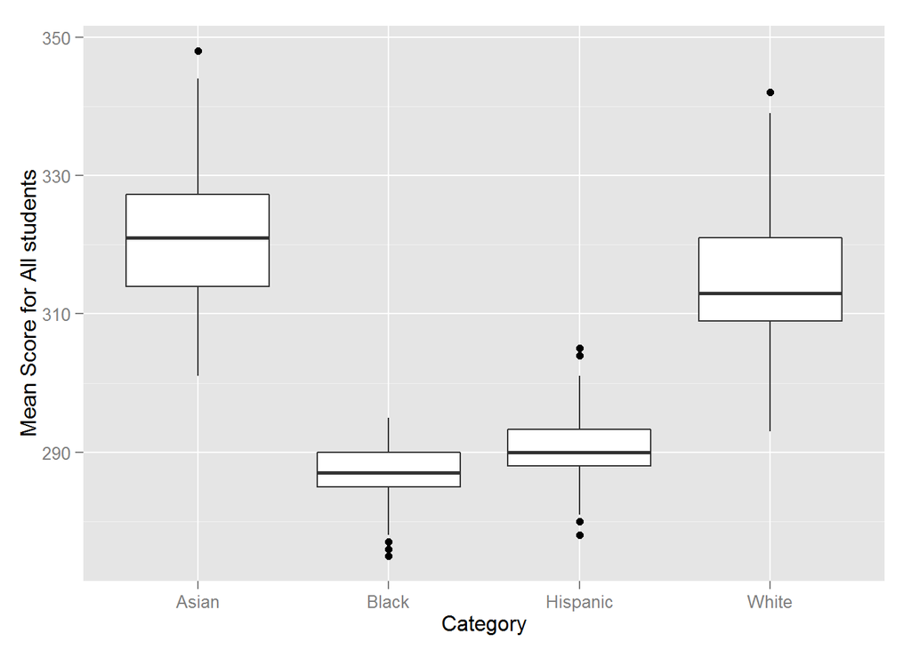

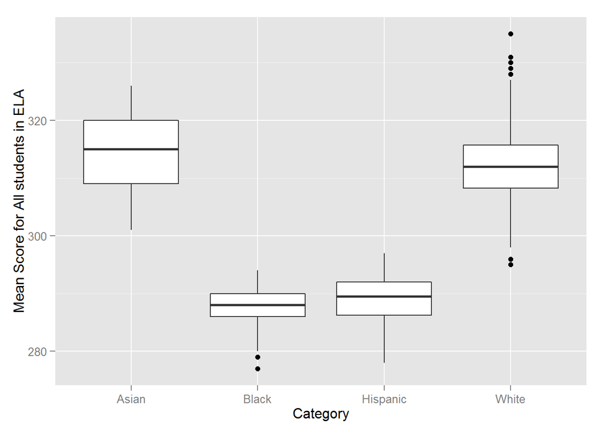

```r
ggplot(subset(borough_data,Category %in% c("Black", "White", "Hispanic", "Asian") & Subject == "ELA"), aes(Category,Mean.Scale.Score)) + geom_boxplot() +  ylab("Mean Score for All students in ELA")
```

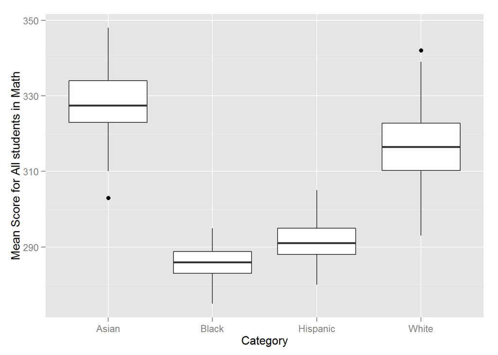

```r
ggplot(subset(borough_data,Category %in% c("Black", "White", "Hispanic", "Asian") & Subject == "Math"), aes(Category,Mean.Scale.Score)) + geom_boxplot() +  ylab("Mean Score for All students in Math")
```

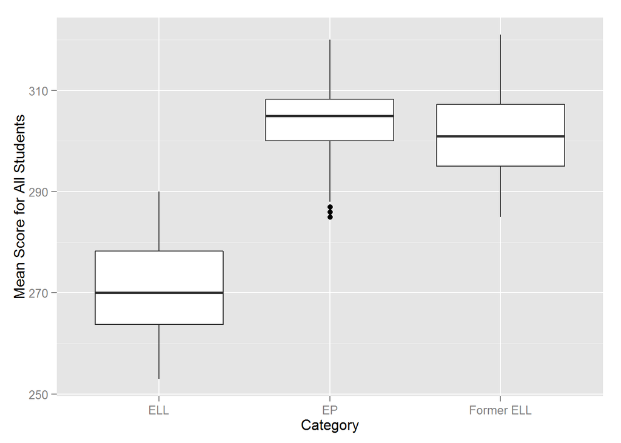

```r
ggplot(subset(borough_data,Category %in% c("ELL", "Former ELL", "EP") ), aes(Category,Mean.Scale.Score)) + geom_boxplot() +  ylab("Mean Score for All Students")
```

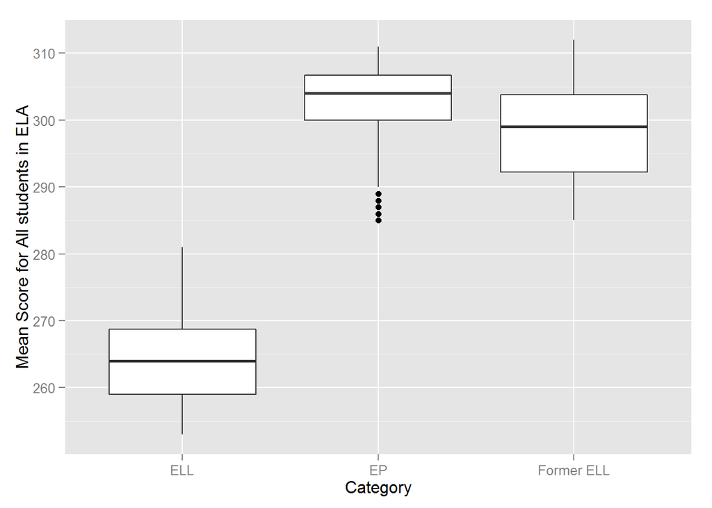

```r
ggplot(subset(borough_data,Category %in% c("ELL", "Former ELL", "EP") & Subject == "ELA"), aes(Category,Mean.Scale.Score)) + geom_boxplot() +  ylab("Mean Score for All students in ELA")
```

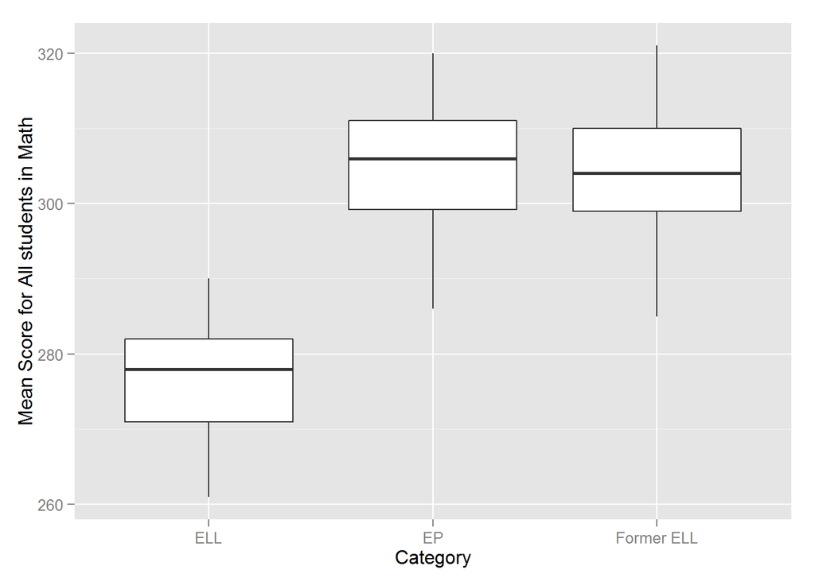

```r
ggplot(subset(borough_data,Category %in% c("ELL", "Former ELL", "EP") & Subject == "Math"), aes(Category,Mean.Scale.Score)) + geom_boxplot() +  ylab("Mean Score for All students in Math")
```

The data shows that English proficient students has the highest median scores which is expected. Given the data, it seems that the barrier of not speaking English is reflective on the test scores outcome. Former English Language Learners seem to do almost as good as English Proficient students.

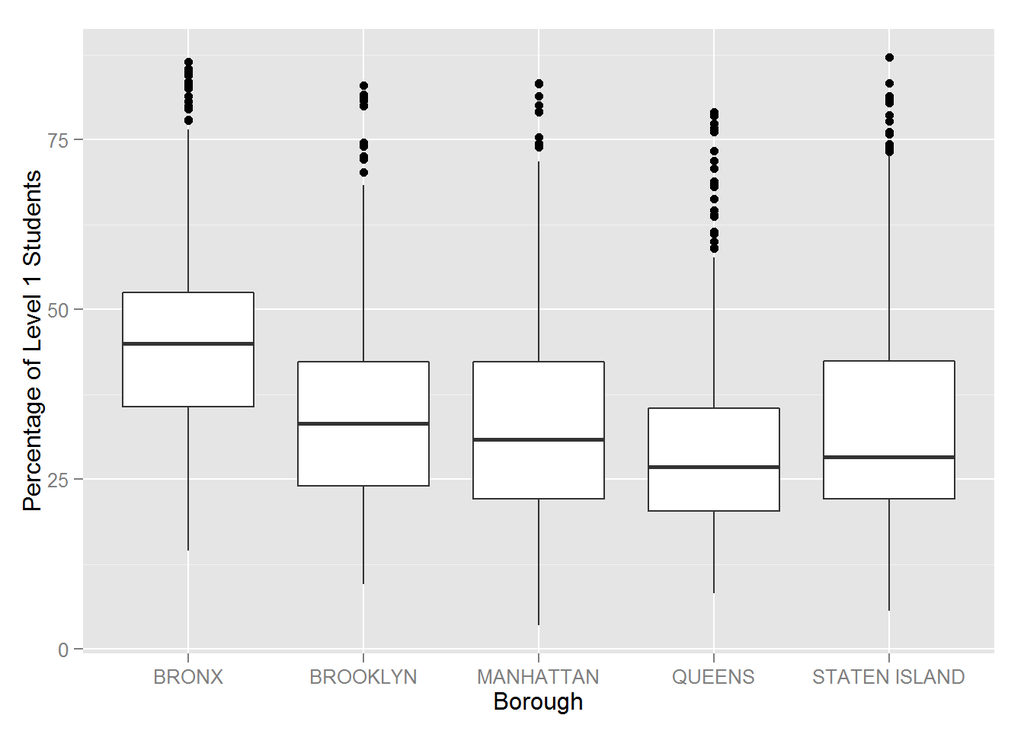

```r
ggplot(borough_data, aes(Borough,Level1Percentage)) + geom_boxplot() +  ylab("Percentage of Level 1 Students")
```

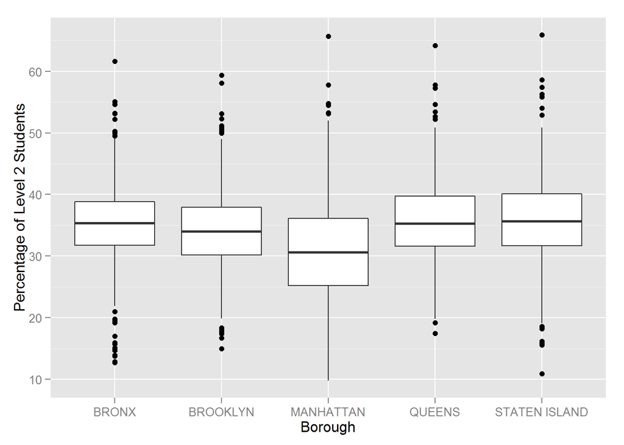

```r
ggplot(borough_data, aes(Borough,Level2Percentage)) + geom_boxplot() + ylab("Percentage of Level 2 Students")
```

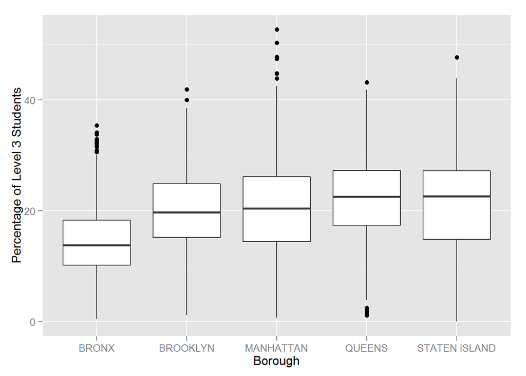

```r
ggplot(borough_data, aes(Borough,Level3Percentage)) + geom_boxplot() + ylab("Percentage of Level 3 Students")
```

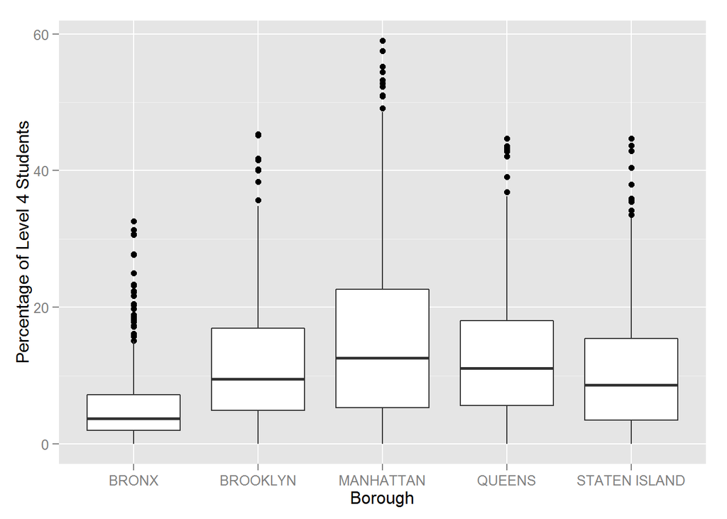

```r
ggplot(borough_data, aes(Borough,Level4Percentage)) + geom_boxplot() + ylab("Percentage of Level 4 Students")
```

I found it interesting that although Queens has relatively the same proportion of Level 2,3 , and 4 , they had the highest median of mean value scores across all the boroughs.

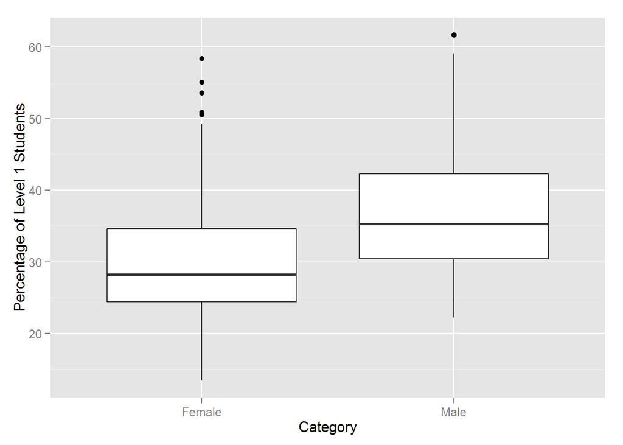

```r
ggplot(subset(borough_data,Category == c("Female", "Male")), aes(Category,Level1Percentage)) + geom_boxplot() +  ylab("Percentage of Level 1 Students")
```

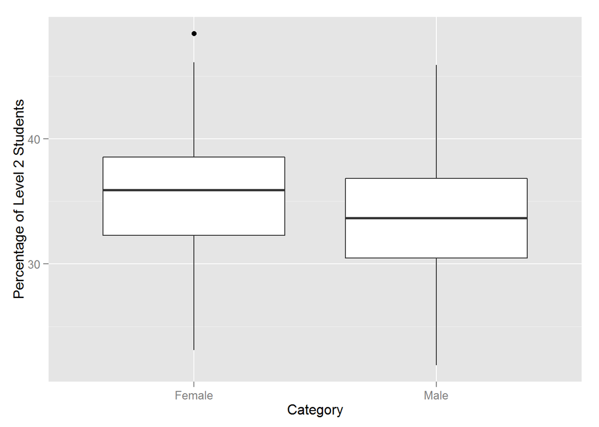

```r
ggplot(subset(borough_data,Category == c("Female", "Male")), aes(Category,Level2Percentage)) + geom_boxplot() + ylab("Percentage of Level 2 Students")
```

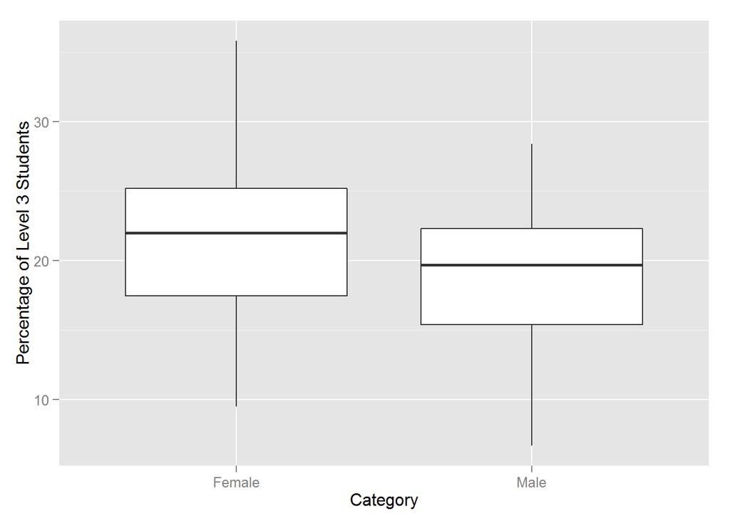

```r
 ggplot(subset(borough_data,Category == c("Female", "Male")), aes(Category,Level3Percentage)) + geom_boxplot() + ylab("Percentage of Level 3 Students")
```

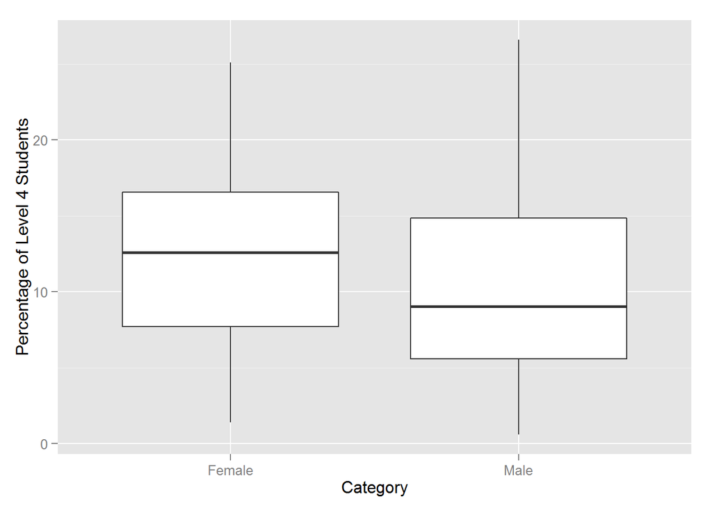

```r
ggplot(subset(borough_data,Category == c("Female", "Male")), aes(Category,Level4Percentage)) + geom_boxplot() + ylab("Percentage of Level 4 Students")
```

It seems that Females were a lower proportion of Level 1 students and a higher proportion of level 2 ,3 and 4 students than males.

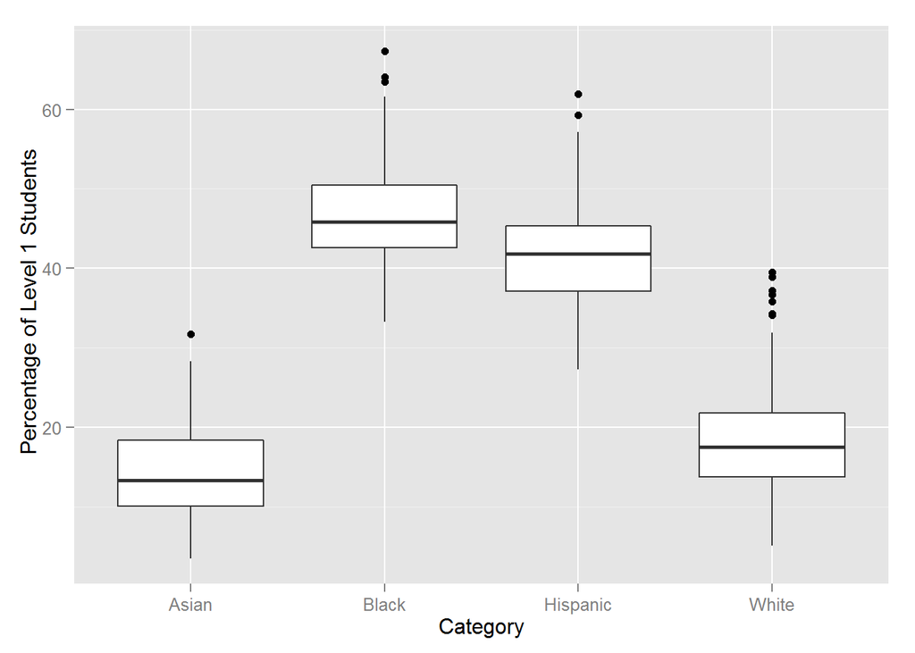

```r
ggplot(subset(borough_data,Category %in% c("Black", "White", "Hispanic", "Asian")), aes(Category,Level1Percentage)) + geom_boxplot() +  ylab(" Percentage of Level 1 Students")
```

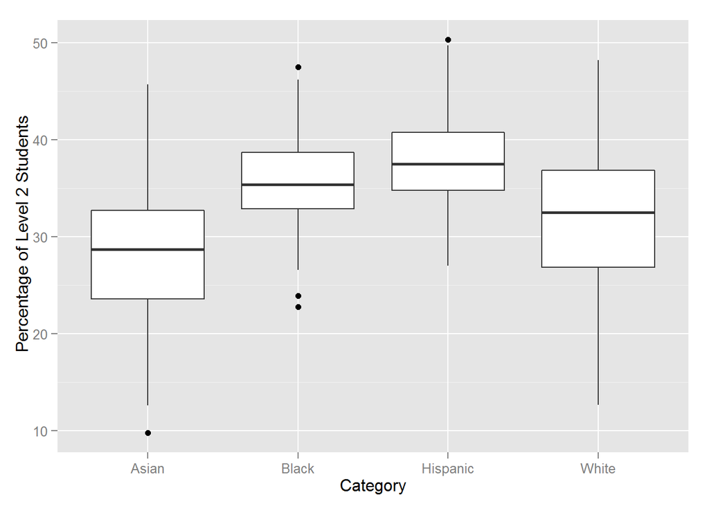

```r
 ggplot(subset(borough_data,Category %in% c("Black", "White", "Hispanic", "Asian")), aes(Category,Level2Percentage)) + geom_boxplot() +  ylab(" Percentage of Level 2 Students")
```

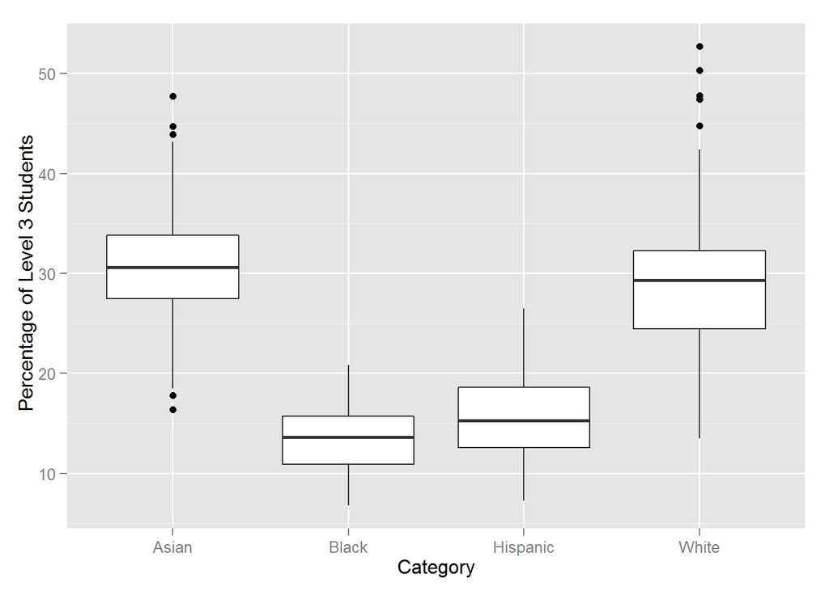

```r
 ggplot(subset(borough_data,Category %in% c("Black", "White", "Hispanic", "Asian")), aes(Category,Level3Percentage)) + geom_boxplot() +  ylab(" Percentage of Level 3 Students")
```

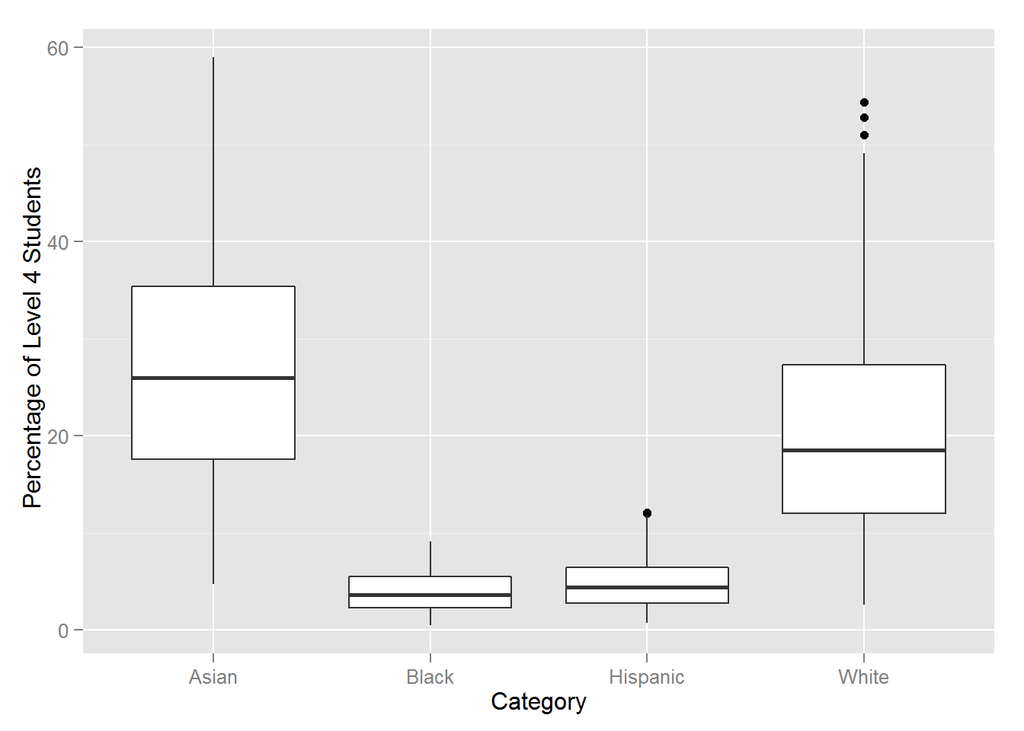

```r
ggplot(subset(borough_data,Category %in% c("Black", "White", "Hispanic", "Asian")), aes(Category,Level4Percentage)) + geom_boxplot() +  ylab(" Percentage of Level 4 Students")
```

Black students had very large number of Level 1 and 2 students with almost 50% of them Level 1. Asian students have the lowest median proportion of level 1 and 2 students and the highest median proportion of level 3 and 4 students. White students had a lower median proportion of level 1 and 2 students in respect to Black and Hispanic students, but had a relatively equal proportion of Level 2 students as well.

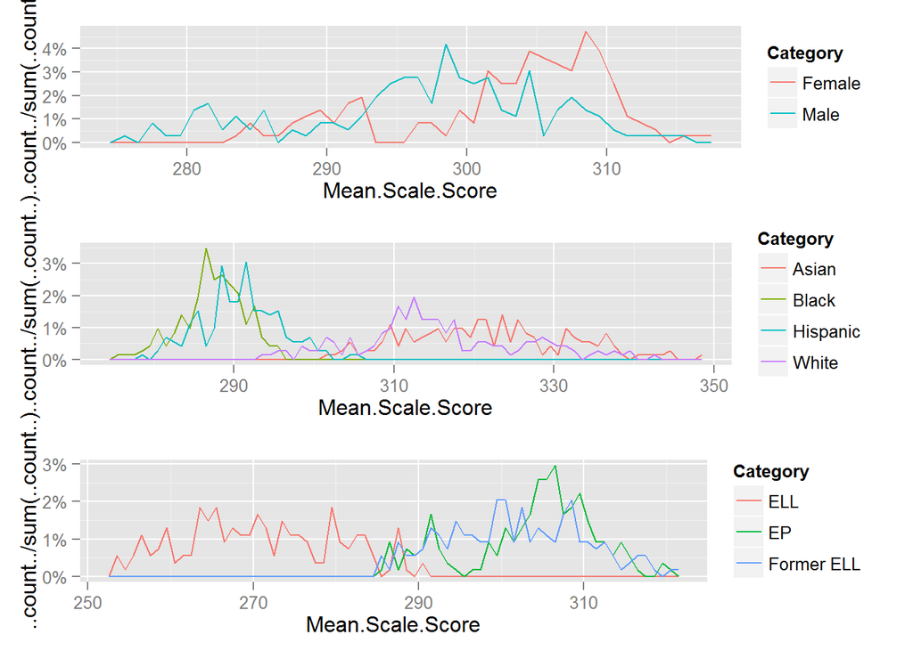

It looks like females begin to overtake males mean score around 303. Males peak at around 297 while females peak around 307. Females min mean score seems to fall around 283. White and Asian mean scores begin to become a higher proportion of their students around 310 where it begins to peak and slowly decreases as the mean score amount get increases. A large proportion of Black and Hispanics’ mean scores fall between 280 and 300. Black Students’ mean score maxes out around 295. Hispanic Students’ mean score maxes out around 305. EP students seem to peak around the same mean score as females do. ELL students are some what evenly spread between the mean scores’ 250 and 290. There seems to be no represetation of ELL students past 292.

# Analyzing Test Data on a School-level Granulatrity 2013-2015

```r
## A separate function for school data was created because the column formats are different
##than the column formats in the borough data.  In the school data we need to convert the
##Percentage columns from "factors" to "characters" first and then convert them to numerics. ##This was done because when converting from "factors" to "numerics", we do not get the same ##initial decimal value.  All observations that have 5 or less students tested have "s"
##values for each column value so we filter those out.
initial_reshape_school_data <- function(df,s){
  df <- subset(df, df$Grade != "All Grades")
  df$Grade <- as.character(df$Grade)
  df$Grade <- as.integer(df$Grade)
  df <- subset(df, Number.Tested > 5)
  df$Number.Tested <- as.integer(df$Number.Tested)
  df$Level1Percentage <- as.character(df$Level1Percentage)
  df$Level2Percentage <- as.character(df$Level2Percentage)
  df$Level3Percentage <- as.character(df$Level3Percentage)
  df$Level4Percentage <- as.character(df$Level4Percentage)

  df$Mean.Scale.Score <- as.numeric(df$Mean.Scale.Score)
  df$Level1Percentage <- as.numeric(df$Level1Percentage)
  df$Level2Percentage <- as.numeric(df$Level2Percentage)
  df$Level3Percentage <- as.numeric(df$Level3Percentage)
  df$Level4Percentage <- as.numeric(df$Level4Percentage)
  df$Subject <- s
  return(df)
}
```

```r
setwd('C:\\Users\\ransf\\Documents\\SchoolData')
df <- read.csv("SchoolMathResults20132015_ALL.csv")
df <- initial_reshape_school_data(df,"Math")
```

```r
setwd('C:\\Users\\ransf\\Documents\\SchoolData')
df1 <- read.csv("SchoolMathResults20132015_ELL.csv")
df1 <- initial_reshape_school_data(df1,"Math")
```

```r
setwd('C:\\Users\\ransf\\Documents\\SchoolData')
df2 <- read.csv("SchoolMathResults20132015_Ethnicity.csv")
df2 <- initial_reshape_school_data(df2,"Math")
```

```r
setwd('C:\\Users\\ransf\\Documents\\SchoolData')
df3 <- read.csv("SchoolMathResults20132015_Gender.csv")
df3 <- initial_reshape_school_data(df3,"Math")
```

```r
math.2013.2015.school <- bind_rows(df,df1)
math.2013.2015.school <- bind_rows(math.2013.2015.school,df2)
math.2013.2015.school <- bind_rows(math.2013.2015.school,df3)

rm(df,df1,df2,df3)
```

```r
setwd('C:\\Users\\ransf\\Documents\\SchoolData')
df <- read.csv("SchoolELAResults20132015_ALL.csv")
df <- initial_reshape_school_data(df,"ELA")
```

```r
setwd('C:\\Users\\ransf\\Documents\\SchoolData')
df1 <- read.csv("SchoolELAResults20132015_ELL.csv")
df1 <- initial_reshape_school_data(df1,"ELA")
```

```r
setwd('C:\\Users\\ransf\\Documents\\SchoolData')
df2 <- read.csv("SchoolELAResults20132015_Ethnicity.csv")
df2 <- initial_reshape_school_data(df2,"ELA")
```

```r
setwd('C:\\Users\\ransf\\Documents\\SchoolData')
df3 <- read.csv("SchoolELAResults20132015_Gender.csv")
df3 <- initial_reshape_school_data(df3,"ELA")
```

```r
ela.2013.2015.school <- bind_rows(df,df1)
ela.2013.2015.school <- bind_rows(ela.2013.2015.school,df2)
ela.2013.2015.school <- bind_rows(ela.2013.2015.school,df3)

school_data <- bind_rows(math.2013.2015.school,ela.2013.2015.school)
rm(math.2013.2015.school,ela.2013.2015.school)
```

I thought that it would be good to add a field for for which borough the school resides in so I wrote a function to perform that action. This is done based on the letter in the DBN number for the school. “M” is for Manhattan, “K” is for Brooklyn, “X” is for the the Bronx, “Q” is for Queens, and “R” is for Staten Island.

```r
## We extract the Borough information by analyzing the DBN for each school.
## If the DBN number has a specific character, then we assign it the appropriate
## Borough
create_borough_vector <- function (v){

  cond <- grepl(".+M.+",v$DBN,perl = TRUE)
  v$Borough <- ifelse(cond,"Manhattan","Other Borough")
  cond <- grepl(".+X.+",v$DBN,perl = TRUE)
  v$Borough <- ifelse(cond,"Bronx",v$Borough)
   cond <- grepl(".+K.+",v$DBN,perl = TRUE)
  v$Borough <- ifelse(cond,"Brooklyn",v$Borough)
   cond <- grepl(".+Q.+",v$DBN,perl = TRUE)
  v$Borough <- ifelse(cond,"Queens",v$Borough)
   cond <- grepl(".+R.+",v$DBN,perl = TRUE)
  v$Borough <- ifelse(cond,"Staten Island",v$Borough)
  return(v)
}
```

```r
school_data <- create_borough_vector(school_data)
```

Since the percentage of level 1,2,3,4 students is the only continuous value field that is in this datset, I thought it would be fitting for Bivaraiate Analysis. The first plot is the Mean Score vs. Level1Percentage.

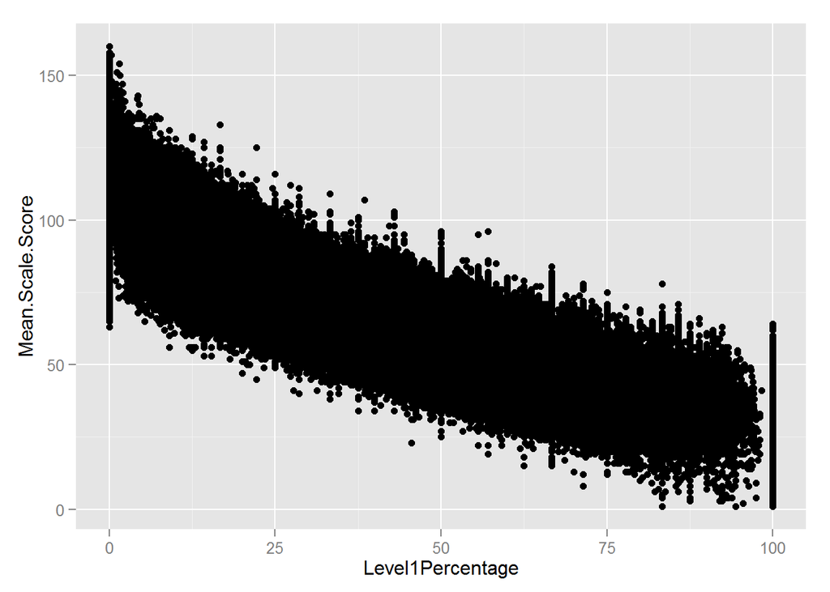

```r
ggplot(school_data, aes(x = Level1Percentage, y = Mean.Scale.Score)) + geom_point()
```

Since there is a lot of overplotting, we use the alpha parameter to reduce it.

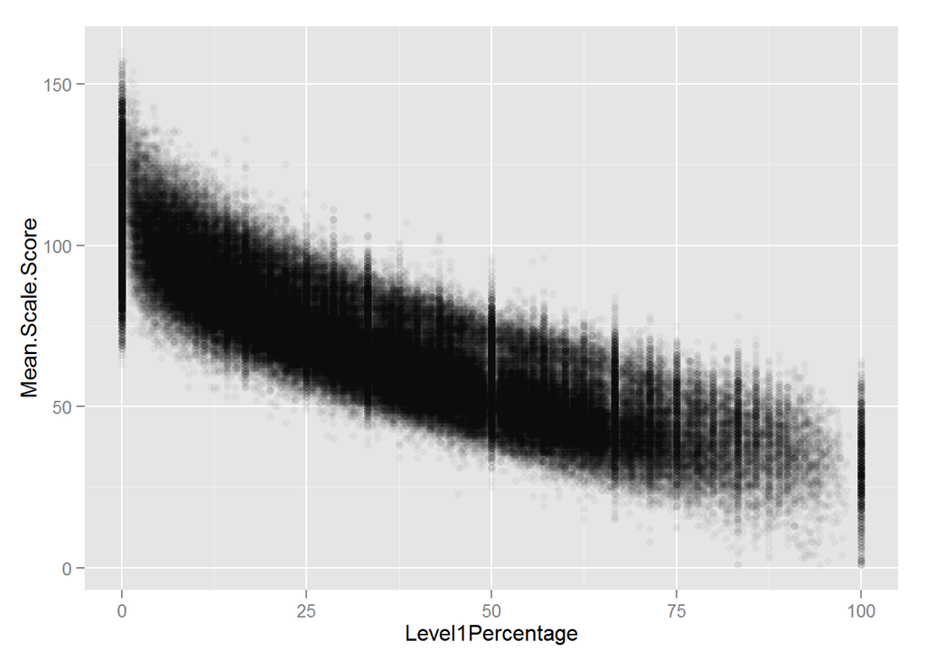

```r
ggplot(school_data, aes(x = Level1Percentage, y = Mean.Scale.Score)) + geom_point(alpha = 1/25)
```

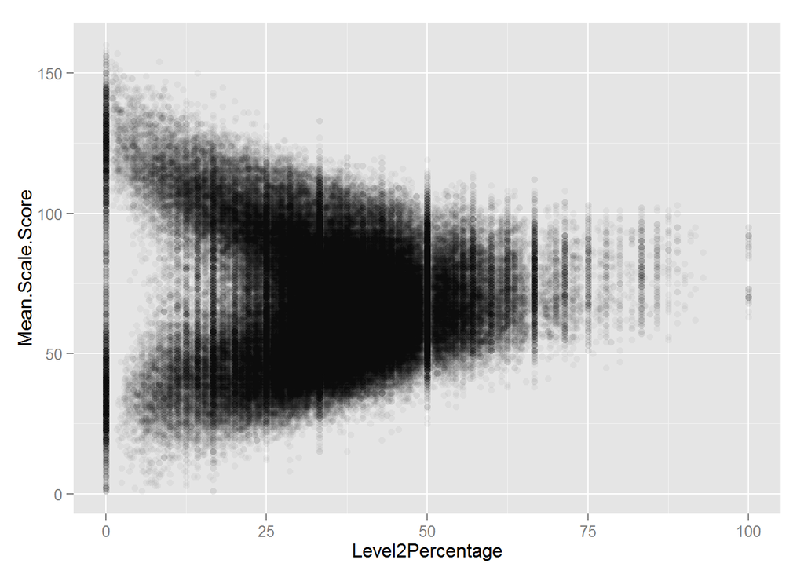

```r
ggplot(school_data, aes(x = Level2Percentage, y = Mean.Scale.Score)) + geom_point(alpha = 1/25)
```

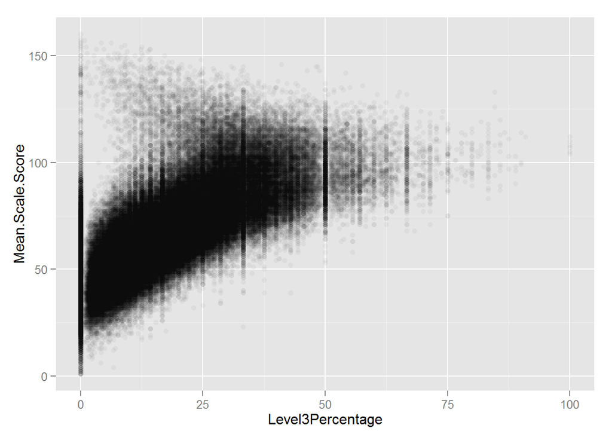

```r
ggplot(school_data, aes(x = Level3Percentage, y = Mean.Scale.Score)) + geom_point(alpha = 1/25)
```

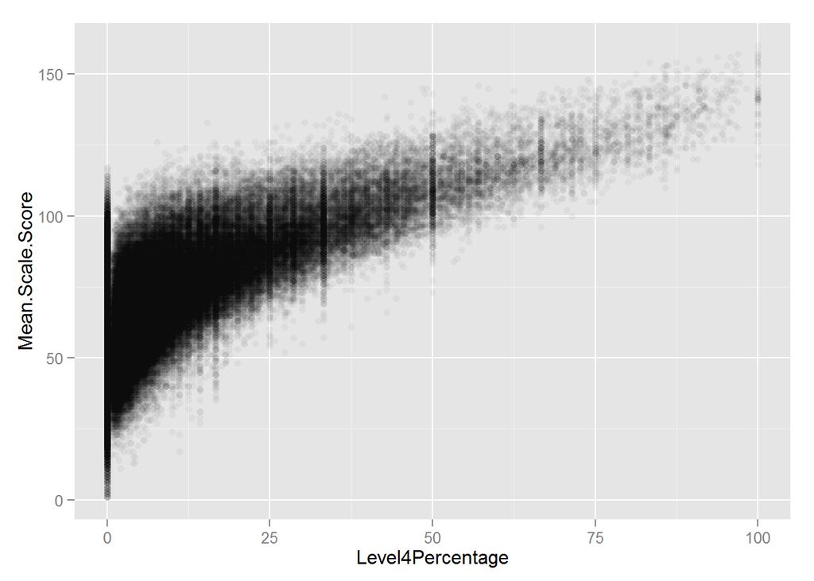

```r
ggplot(school_data, aes(x = Level4Percentage, y = Mean.Scale.Score)) + geom_point(alpha = 1/25)
```

Now that we have a good field for the data for the past two years, lets wrangle the older data and combine it with the most recent data to see if we can see any trends. While looking at the data from 2006-2012, I noticed that the mean scores were higher in the older data than in the 2013-2015 Data. After doing some searching on the web, I found this [site](http://www.p12.nysed.gov/irs/ela-math/). The documents here show that the score scales vary year over year, so using the mean scale score will not be very useful when combining data from 2006-2012 with data from 2013-2015.